# some_integration_steps

## Try to integrate

```python
from temp import temp as temp
import galpy.df
import numpy as np
import matplotlib.pyplot as plt
import matplotlib as mpl
```

```python
W0 = 10
nparticles = 10
myking = galpy.df.kingdf(W0,npt=1000)
R,vR,vT,z,vz,phi=myking.sample(n=nparticles,return_orbit=False)
xp,yp,zp = R*np.cos(phi),R*np.sin(phi),z
vxp,vyp,vzp = vR*np.cos(phi) - vT*np.sin(phi),vR*np.sin(phi) + vT*np.cos(phi),vz
```

```python
temp.initialize_king_potential_profile(W0,1000)
# extract the potential and the force
r_=temp.r_.copy()
W_=temp.w_.copy()
dWdr_=temp.dwdr_.copy()
```

```python
# estimate the dynamical times
v = np.sqrt(vxp**2 + vyp**2 + vzp**2)
r = np.sqrt(xp**2 + yp**2 + zp**2)
tdynam = r/v
dt = 1e-3*tdynam.min()
nstep = 300000
ttotal = nstep*dt
print("estimated dynamical time",tdynam.min())
print("estimated total time",ttotal)
```

```
estimated dynamical time 0.0022454889945294943
estimated total time 0.6736466983588483
```

```python
xt,yt,zt,vxt,vyt,vzt =temp.leapfrog(dt,nstep,xp,yp,zp,vxp,vyp,vzp,)
```

```python
phis=np.zeros((nparticles,nstep+1))
kinetic_energy = 0.5*(vxt**2 + vyt**2 + vzt**2)

for i in range(nstep+1):
    phis[:,i] = temp.king_unscaled([W0],xt[:,i],yt[:,i],zt[:,i])[3]

energy = kinetic_energy + phis
dE = np.zeros_like(energy)
for i in range(nparticles):
    dE[i] = np.abs(np.sqrt((energy[i] - energy[i,0])**2)/energy[i,0])
E0=energy[:,0]
```

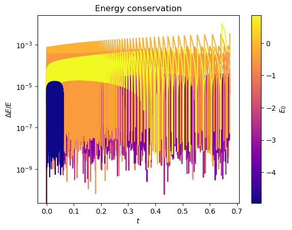

```python
norm = mpl.colors.Normalize(vmin=E0.min(),vmax=E0.max())
cmap = mpl.cm.plasma
colors = cmap(norm(E0))
fig,axis=plt.subplots(1,1)
time = np.arange(nstep+1)*dt
for i in range(nparticles):
    axis.plot(time,dE[i],color=colors[i])
axis.set_yscale("log")
axis.set_xlabel(r"$t$")
axis.set_ylabel(r"$\Delta E/E$")
axis.set_title("Energy conservation")
cbar=fig.colorbar(mpl.cm.ScalarMappable(norm=norm,cmap=cmap),ax=axis,label=r"$E_0$")
```

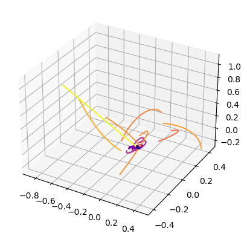

```python
fig= plt.figure()
axis=fig.add_subplot(111,projection="3d")
for i in range(nparticles):
    axis.plot(xt[i,:],yt[i,:],zt[i,:],'-',color=colors[i])
```

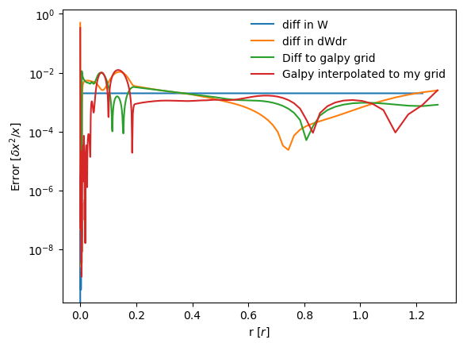

```python
fig,axis=plt.subplots(1,1)
# axis.plot(myking._scalefree_kdf._r,myking._scalefree_kdf._dWdr)
deltaW = W_-myking._scalefree_kdf._W
errorW = np.sqrt(deltaW**2) / np.abs(myking._scalefree_kdf._W)
delta = dWdr_-myking._scalefree_kdf._dWdr
error = np.sqrt(delta**2) / np.abs(myking._scalefree_kdf._dWdr)
deltaR = r_-myking._scalefree_kdf._r
errorR = np.sqrt(deltaR**2) / np.abs(myking._scalefree_kdf._r)
# what if we reinterpolate onto the same grid?
dWdr_interp = np.interp(r_,myking._scalefree_kdf._r,myking._scalefree_kdf._dWdr)
delta_interp = dWdr_interp - dWdr_
error_interp = np.sqrt(delta_interp**2) / np.abs(dWdr_)
axis.plot(r_,errorW,label="diff in W")
axis.plot(r_,error,label="diff in dWdr")
axis.plot(r_,errorR,label="Diff to galpy grid")
axis.plot(myking._scalefree_kdf._r,error_interp,label="Galpy interpolated to my grid")
axis.set_yscale("log")
axis.legend(frameon=False)
axis.set_ylabel(r"Error [$\delta x^2 /x$]")
axis.set_xlabel(r"r [$r$]")
temp.deallocate_all()
```

## What if I just load in galpy's king profile?

```python
from temp import temp
import galpy.df
import numpy as np
import matplotlib.pyplot as plt
import matplotlib as mpl
```

```python
W0=10
npoints = 1000
myking=galpy.df.kingdf(W0,npt=npoints)
r=myking._scalefree_kdf._r
w = myking._scalefree_kdf._W
dwdr = myking._scalefree_kdf._dWdr
temp.load_unscaled_king(r,w,dwdr)
```

```python
nparticles = 100
R,vR,vT,z,vz,phi=myking.sample(n=nparticles,return_orbit=False)
xp,yp,zp = R*np.cos(phi),R*np.sin(phi),z
vxp,vyp,vzp = vR*np.cos(phi) - vT*np.sin(phi),vR*np.sin(phi) + vT*np.cos(phi),vz
```

```python
# time step stuff
# estimate the dynamical times
v = np.sqrt(vxp**2 + vyp**2 + vzp**2)
r = np.sqrt(xp**2 + yp**2 + zp**2)
tdynam = r/v
dt = 1e-3*tdynam.min()
total_time = 4*np.median(tdynam)
nstep = int(total_time/dt)
# nstep = int(10)
print("estimated dynamical time",tdynam.min())
print("estimated total time",total_time)
print("nstep",nstep)
```

```
estimated dynamical time 0.001621615783593584
estimated total time 0.3844178629084155
nstep 237058
```

```python
# now compute the orbits
xt,yt,zt,vxt,vyt,vzt =temp.leapfrog(dt,nstep,xp,yp,zp,vxp,vyp,vzp,)
ntskip = 100
xt=xt[:,::ntskip]
yt=yt[:,::ntskip]
zt=zt[:,::ntskip]
vxt=vxt[:,::ntskip]
vyt=vyt[:,::ntskip]
vzt=vzt[:,::ntskip]
```

```python
phis=np.zeros_like(vyt)
kinetic_energy = 0.5*(vxt**2 + vyt**2 + vzt**2)

for i in range(nstep//ntskip):
    phis[:,i] = temp.king_unscaled([W0],xt[:,i],yt[:,i],zt[:,i])[3]

energy = kinetic_energy + phis
dE = np.zeros_like(energy)
for i in range(nparticles):
    dE[i] = np.abs(np.sqrt((energy[i] - energy[i,0])**2)/energy[i,0])
E0=energy[:,0]
```

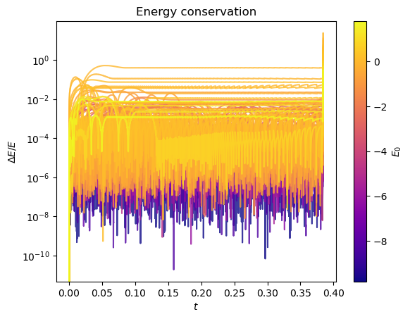

```python
norm = mpl.colors.Normalize(vmin=E0.min(),vmax=E0.max())
cmap = mpl.cm.plasma
colors = cmap(norm(E0))
fig,axis=plt.subplots(1,1)
time = np.arange(nstep+1)*dt
for i in range(nparticles):
    axis.plot(time[::ntskip],dE[i],color=colors[i],zorder=E0[i],alpha=0.8)
axis.set_yscale("log")
axis.set_xlabel(r"$t$")
axis.set_ylabel(r"$\Delta E/E$")
axis.set_title("Energy conservation")
cbar=fig.colorbar(mpl.cm.ScalarMappable(norm=norm,cmap=cmap),ax=axis,label=r"$E_0$")
```

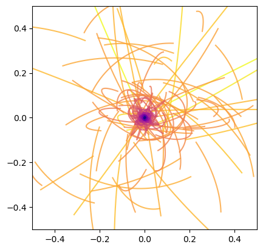

```python
fig,axis=plt.subplots(1,1)
for i in range(nparticles):
    axis.plot(xt[i,:],yt[i,:],'-',color=colors[i],zorder=-E0[i],alpha=0.8)
limit=0.5
axis.set_xlim(-limit,limit)
axis.set_ylim(-limit,limit)
axis.set_aspect("equal")
temp.deallocate_all()
```

NOTES

- difficulty solving king potential with 100% accuracy
- problem with duplicate W for the first step of my runge kutta method
- I check the data by print the points and looping at the slopes $(k_1,k_2,k_3,k_4)$ and the slopes cancel out
- this doesn't happen when I try scipy's rk45, which is not exactly the same but nonetheless.
- The conservation of energy doesn't seem that good.
- However, it doesn't seem to change that much when I add galpy's solution manually against my own
- perhaps I could interpolate better
- OR I could augment the data points... that would be an easy check.
- maybe it's good enough to implement? I want to check galpy's error

```python
from galpy.orbit import Orbit
from galpy.potential import KingPotential
from galpy.df import kingdf
import numpy as np
import matplotlib.pyplot as plt
import matplotlib as mpl

# generate 100 particles within a king potential and integrate them
nparticles = 100
W0 = 10
M=1
rt=1
myking = kingdf(W0,M=1,rt=1)
R,vR,vT,z,vz,phi=myking.sample(n=nparticles,return_orbit=False)
# compute the dynamic time
v = np.sqrt(vR**2 + vT**2 + vz**2)
r = np.sqrt(R**2 + z**2)
tdynam = r/v
dt = 1e-3*tdynam.min()
# nstep = 300000
# ttotal = nstep*dt
# t= np.arange(nstep+1)*dt
o=Orbit(vxvv=[R,vR,vT,z,vz,phi])
# mypotential = KingPotential(ro=1.,vo=1.,W0=W0)
# o.integrate(t=t, pot=mypotential)
mypot=KingPotential(W0=W0,M=M,rt=rt)
```

```python
ts = np.linspace(0,10*np.median(tdynam),1000)
o.integrate(ts,mypot)
xs = o.x(ts)
ys = o.y(ts)
E = o.E(ts)
```

```python
E0=E[:,0]
deltaE = np.zeros_like(E)
for i in range(nparticles):
    deltaE[i] = np.abs(np.sqrt((E[i] - E0[i])**2)/E0[i])
```

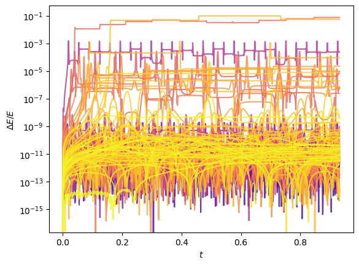

```python
norm = mpl.colors.Normalize(vmin=E0.min(),vmax=E0.max())
cmap = mpl.cm.plasma
colors = cmap(norm(E0))
fig,axis=plt.subplots(1,1)
for i in range(nparticles):
    axis.plot(ts,deltaE[i],color=colors[i],zorder=E0[i],alpha=0.8)
axis.set_yscale("log")
axis.set_xlabel(r"$t$")
axis.set_ylabel(r"$\Delta E/E$")
```

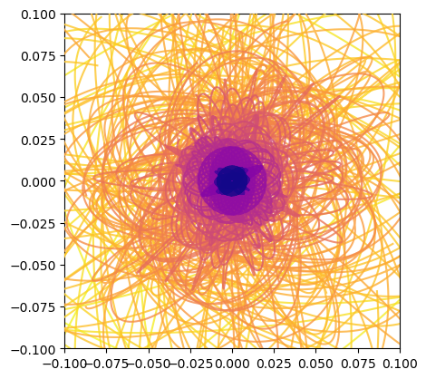

```python
fig,axis=plt.subplots(1,1)
for i in range(nparticles):
    axis.plot(xs[i,:],ys[i,:],'-',color=colors[i],zorder=-E0[i],alpha=0.8)
limit=0.1
axis.set_xlim(-limit,limit)
axis.set_ylim(-limit,limit)
axis.set_aspect("equal")
```